# Modeling Systems and Variables

## System

System dynamics is the interaction betwwen a system and it's environment.

$\textbf{System}$ : A group of components or concepts contained within a real or imaginary boundary. Usually a system is designed to perform intended function. Systems can be logically decomposed into sub-systems. In addition, a system can be interfaced to another system.

$\textbf{Environment}$: Anything outside of a system is the environment.

The interaction between a system and its environment is characterized in terms of a set of system variables, which in engineering systems may be timevarying physical quantities such as forces, voltages, or pressures or mathematical variables with no direct physical context. These variables may be internal to the system and reflect the state of an element, for example, the force acting on a spring, or they might express the time variation of some quantity at the interface between the system and its environment. It is useful to define two important classes of system variables:

$\textbf{Inputs}$: An input is a system variable that is independently prescribed, or defined, by the system's environment The value of an input at any instant is independent of the system behavior or response. Inputs define the external excitation of the system and can be quantities such as the external wind force acting on a tall building system or the rainfall forming the input flow into a reservoir system. A system may have more than one input.

$\textbf{Outputs}$: An output is defined as any system variable of interest. It may be a variable measured at the interface with the environment or a variable that is internal to the system and does not directly interact with the environment

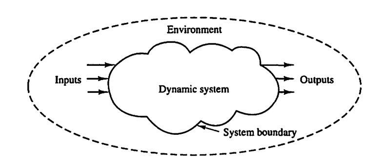

$\textbf{System State}$: The definition of a state-determined system model is developed from the concept of system state, is represented by the specification of a minimum set of variables, known as state variables, that uniquely define the system response at any given time. The mathematical model of the system is given by a set of state equations.

## System Modeling

The formulation of state-determined system models of physical systems requires

1. selection of a set of primitive elements (spring, damper, capacitor, inductor, etc.) to represent the energy interaction within a system and between a system and its environment, and
2. definition of the system structure or the manner in which the primitive elements are connected.

A lumped element\parameter modeling of a system is a frequently used approach to model complex system interms of interconnected primitive elements.

$\textbf{Example}$

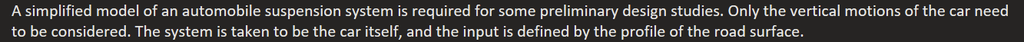

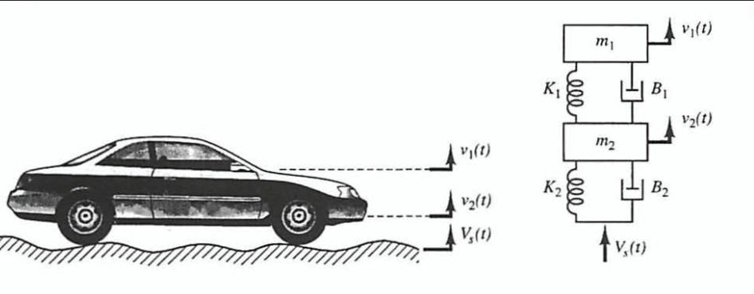

$\textbf{Through Variable :}$

Variable that passes through the system components. Must be measured by placing prob in a series connection.

$\textbf{Accross Variable :}$

Variable that appears accross two terminals of a system component. Must be measured by placing probe accross two terminal.

$\textbf{Governing Equation :}$

$$\sum \vec{F} = m \cdot \vec{a}$$

$$\sum \vec{\tau} = I \cdot \vec{\alpha}$$

$$\sum_{loop} \Delta V = 0$$

$$\sum_{node} I = 0$$

$\textbf{Constitutive Equation :}$

$$F_{spring} = K*X$$

$$F_{damper} = C*\dot{X}$$

$$C \cdot \frac{dv_c}{dt} = i_c$$

$$L \cdot \frac{di_L}{dt} = v_L$$

## Power Flow and Units

A set of primitive elements that form the basis for construction of dynamic models of a physical system may be defined from the energy flows within the system and between the system and its environment.

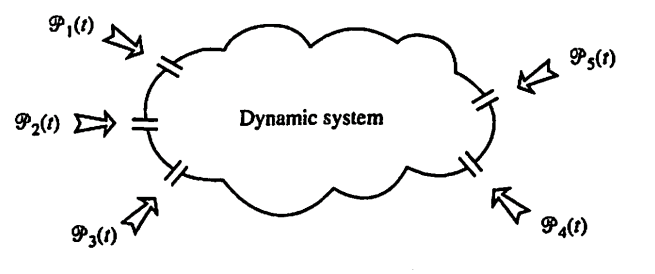

$\textbf{Equations}$

Mechanical Translational System (linear motion e.g. car suspension)

$$Power = force(f) * velocity(v) $$

Mechanical rotational System (rotational motion, e.g. motor)

$$Power = torque(\tau) * Angular\ velocity(\omega) $$

Electrical System

$$Power = Voltage(V) * Current(I)$$

In physical system models, the system parameters and variables are ~xpressed in terms of specific measures or units. Each physical quantity may be described in terms of a set of generalized dimensions such as length and time. For example, the dimension of the unit of meter or foot is length, and of area is length squared. In a consistent set of units, a minimal set of fundamental dimensions may·be defined in terms of particular units, and then all other quantities may be defined in terms of the units of these fundamental dimensions.

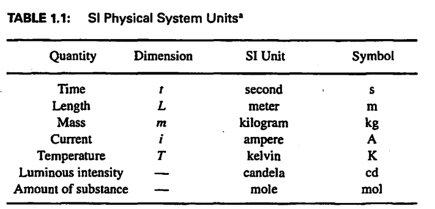

# Mechanical System

## Basic Kinematics

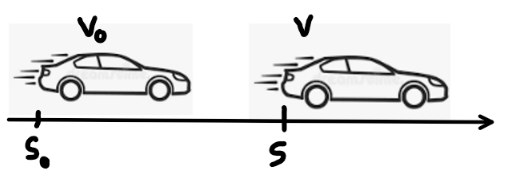

When acceleration $a$ is constant, following equations can be used

$\bullet$ Velocity is the time rate of change of position

$$ v = \frac{ds(t)}{dt} $$

$\bullet$ Acceleration is the time rate of change of velocity

$$ a = \frac{dv(t)}{dt} $$

$\bullet$ Velocity as a function of time: $$ V(t) = V_0 + a \cdot t $$ $\bullet$ Position as a function of time: $$ S(t) = S_0+ V_0 \cdot t + \frac{1}{2} \cdot a \cdot t^{2} $$ $\bullet$ Velocity as a function of position: $$ V(s) = \sqrt{V^{2}_0 + 2 \cdot a \cdot (s-s_0)} $$

$s_0$ and $v_0$ are initial position and initial velocity.

### Example 1

The position function of a moving body with constant acceleration of $2 \ \frac{m}{s^2}$ is given as $S(t) = 3 + 2 \cdot t + t^2$. Plot the position function in MATLAB. Mark the position at $5 \ sec$

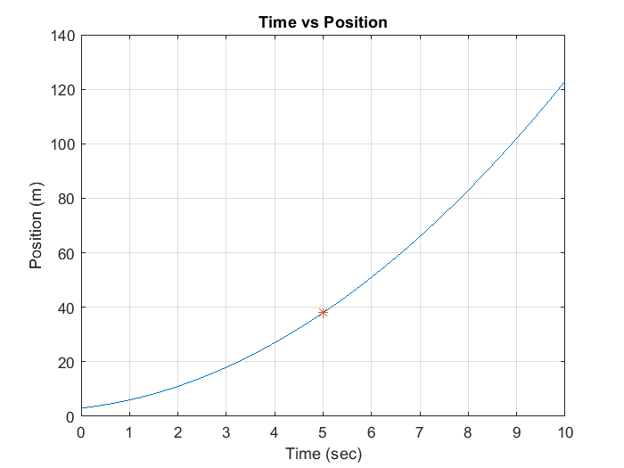

```matlab
% define the function
S=@(t) 3+2*t+t.^2 ;

% define time vector
t = linspace(0,10);

figure
plot(t,S(t)) % time vs position plot
hold on
plot(5,S(5),'*') % marks the position at 5 sec
grid on
xlabel('Time (sec)');
ylabel('Position (m)');
title('Time vs Position');
```

## Linear Vs Circular

$\bullet$ $s = r \cdot \theta$

$\bullet$ $v = r \cdot \omega$

$\bullet$ $a = r \cdot \alpha$

$\bullet$ $I = \sum{m \cdot r^{2}}$ (moment of inertia)

## Laws of Motion

$\bullet$ Newton's Second law for rectilinear motion $\sum{\vec{F}} = m \cdot \vec{a} $

$\bullet$ Rotational motion $\sum{\vec{\tau}} = I \cdot \vec{\alpha} $

$\bullet$ Centripetal Force $F_c = m \cdot \omega^{2} \cdot r$

## Energy Equation

$\bullet$ $PE = mgh$

$\bullet$ $KE = \frac{1}{2}\cdot m \cdot v^{2}$

## Primitive Elements

$\bullet$ Spring $F_s = K \cdot (x_e - x)$

$\bullet$ Damper $F_d = C \cdot \frac{x_e - x}{\delta t} = C \cdot \dot{x}$

$\bullet$ Equivalent Stiffness for Parallel spring $K_{eq} = K_1 + K_2 + ... + K_n$

$\bullet$ Equivalent Stiffness for series spring $K_{eq} = \frac{1}{K_1}+ \frac{1}{K_2} + ... + \frac{1}{K_n}$

## Mechanical System Response

### Periodic Motion

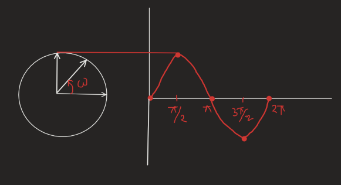

$$V(t) = A \cdot sin(\omega t + \phi)$$

$$\omega = 2\pi *f \ (f \ is \ frequency)$$

$$\phi = phase \ angle$$

$$A = Amplitude$$

### Time Domain Analysis

$\textbf{Mass-Spring-Damper Generelized Equation}$

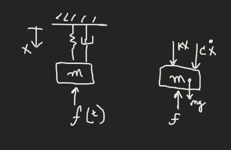

$$m \cdot \ddot{x(t)} + c \cdot \dot{x(t)} + k \cdot x(t) = f(t) - mg ----(1)$$

$\textbf{State Space Model}$

define state vector

$$\vec{\mathbf{X}}= \begin{bmatrix} x_1 \\ x_2 \end{bmatrix} $$

$x_1:$ velocity and $x_2:$ position

rewrite the equation (1) interms of desired states

$$ \ddot{x(t)} = \frac{-c}{m} \dot{x(t)} + \frac{-k}{m} x(t) + \frac{1}{m}(f(t)-mg)$$

define input vector

$$\vec{\mathbf{U}}= \begin{bmatrix} u_1 \\ u_2 \end{bmatrix} $$

$u_1:$ $f(t)-mg$ ;

$u_2:$ 0

Now we can write defferential equation in-terms of state variables required for state space model

$$ \dot{x_1} = \frac{-c}{m} x_1 + \frac{-k}{m} x_2 + \frac{1}{m}u_1 + 0u_2$$ $$ \dot{x_2} = 1x_1+ 0x_2 + 0u_1+0u_2$$

define system matrix $[A]$

\begin{bmatrix} -c/m & -k/m \\ 1 & 0 \end{bmatrix}

define input matrix $[B]$

\begin{bmatrix} 1/m & 0 \\ 0 & 0 \end{bmatrix}

The State Equation is

$$\dot{\vec{X}} = A\vec{X}+B\vec{U}$$

A system output is defined to be any system variable of interest. A description of a physical system in terms of a set of state variables does not necessarily include all the variables of direct engineering interest. Therefore, an output vector $\vec{Y}$ is defined such that it conatins desired states from the state vector.

Te output equation is

$${\vec{Y}} = C\vec{X}+D\vec{U}$$

For this example we want all of our state variables as an output and we dont have any input feeding to our output. Therefeore,

matrix $[C]$

\begin{bmatrix} 1 & 0 \\ 0 & 1 \end{bmatrix}

matrix $[D]$

\begin{bmatrix} 0 & 0 \\ 0 & 0 \end{bmatrix}

MATLAB DOCUMENTATION FOR STATE SPACE MODEL [ https://www.mathworks.com/help/control/ref/ss.html ]

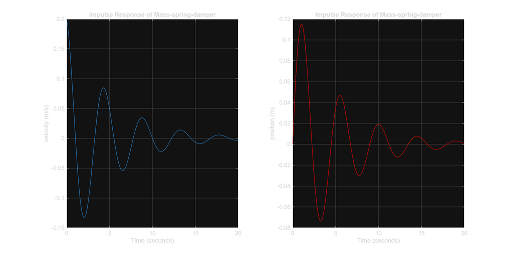

```matlab
clear;
clc;
close all;

%param
m = 5; % mass
c = 2; % damping
k = 10; % stiffness

A = [-c/m,-k/m;1,0]; % System Matrix
B = [1/m,0;0,0]; % Input Matrix
C = [1,0 ; 0 , 1]; % Output Matric
D = [0,0;0,0]; % Feed Forward Matrix

% define state space object
sys = ss(A,B,C,D,'StateName',{'vel' 'pos'},...
    'InputName','force');


t = linspace(0,20,200); % time vector
y = impulse(sys,t); % output/response vector array

% Plotting
figure('Position', [100, 100, 1200, 600]);
subplot(1, 2, 1);
plot(t,y(:,1));
title('Impulse Response of Mass-spring-damper');
ylabel('velocity (m/s)');
xlabel('Time (seconds)');
grid on
hold on
subplot(1, 2, 2);
plot(t,y(:,2),'r')
title('Impulse Response of Mass-spring-damper');
ylabel('position (m)');
xlabel('Time (seconds)');
grid on;
```

# Electrical System

```
ans = 1×2 double
   200     2
```

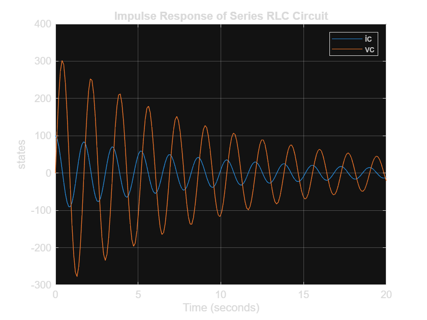

```matlab
clear;
clc;
close all;

%param
R = 2;
L = .01;
C = .001;

A = [-R*C/L,-1/L;1/C,0];
B = [1/L;0];
C = [1,0 ; 0 , 1];
D = 0;
Ts = 0;
sys = ss(A,B,C,D,'StateName',{'ic' 'vc'},...
    'InputName','volt');

% Plot the impulse response
t = linspace(0,20,200);
y = impulse(sys,t);
size(y)

figure;
plot(t,y(:,1));
grid on
hold on
plot(t,y(:,2))
title('Impulse Response of Series RLC Circuit');
ylabel('states');
xlabel('Time (seconds)');
legend('ic','vc')
grid on;
```

```
ans = 1×2 double
   200     2
```

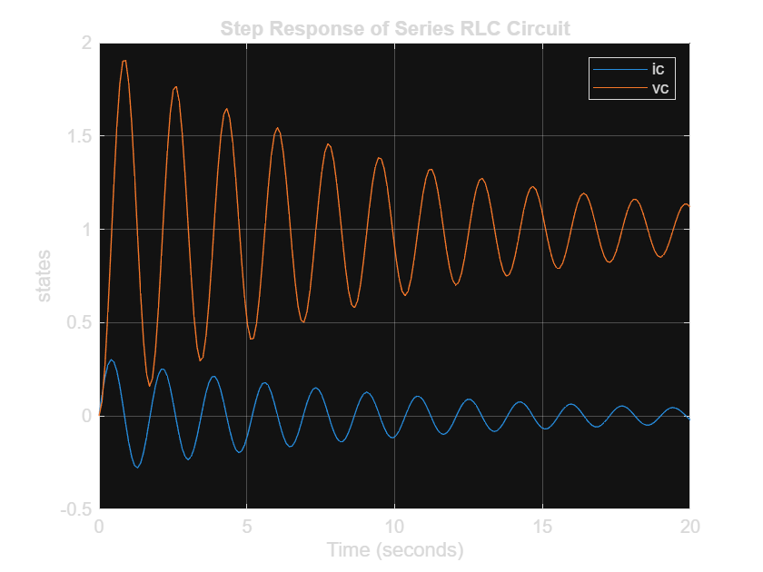

```matlab
clear;
clc;
close all;

%param
R = 2;
L = .01;
C = .001;

A = [-R*C/L,-1/L;1/C,0];
B = [1/L;0];
C = [1,0 ; 0 , 1];
D = 0;
Ts = 0;
sys = ss(A,B,C,D,'StateName',{'ic' 'vc'},...
    'InputName','volt');

% Plot the impulse response
t = linspace(0,20,200);
y = step(sys,t);
size(y)

figure;
plot(t,y(:,1));
grid on
hold on
plot(t,y(:,2))
title('Step Response of Series RLC Circuit');
ylabel('states');
xlabel('Time (seconds)');
legend('ic','vc')
grid on;
```